# Module 5: Data Analysis Methods

Somali Fish Stock Training

Dr. Masumbuko Semba

lugosemba@gmail.com

Nelson Mandela African Institution of Science and Technology

Dr. Rushingisha George

george.rushingisha@tafiri.go.tz

Tangania Fisheries Research Institute

Dr. Mary Kishe

mary.kishe@tafiri.go.tz

Tanzania Fisheries Research Institute

Dr. Ismael Kimirei

ismael.kimirei@tafiri.go.tz

Tanzania Fisheries Research Institute

2025-12-05

## Welcome to Module 5

**Data Analysis Methods**

### Learning Objectives

- Master descriptive statistics
- Apply statistical tests appropriately
- Create publication-quality visualizations
- Interpret results correctly
- Communicate findings effectively

### Why This Matters

- **Transforms clean data into insights**
- Statistics reveal patterns & trends
- Visualizations communicate clearly
- Proper interpretation prevents errors
- Evidence-based decisions require rigor

## The Analysis Framework

### Five-Step Process:

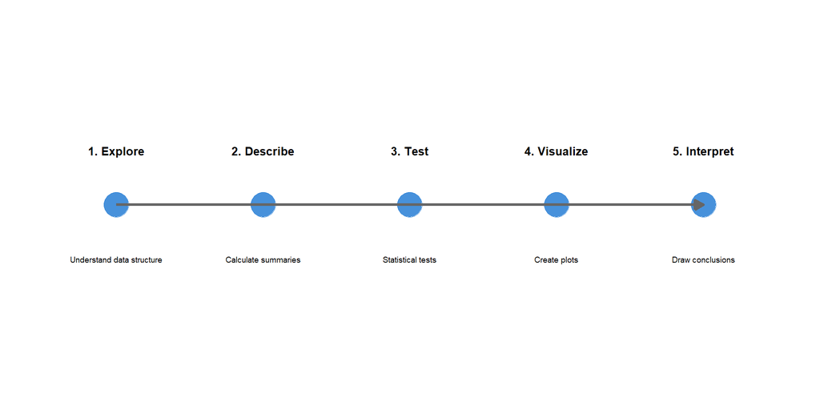

## Step 1: Exploratory Data Analysis (EDA)

### Understand Your Data Structure:

```r
# Get overview
glimpse(data)
str(data)

# Check dimensions
dim(data)

# List variables and types
names(data)
data_types <- sapply(data, class)

# Quick summary
summary(data)
```

## EDA: Missing Data Inspection

### Visualize Missing Patterns:

```r
library(naniar)

# Summary of missing values
data |>
  miss_var_summary() |>
  arrange(desc(pct_miss))

# Visualize missing data pattern
vis_miss(data)

# Check if missingness is random
mcar_test(data)
```

## EDA: Distribution Exploration

### Check Data Distributions:

```r
# Univariate distributions
data |>
  select(where(is.numeric)) |>
  pivot_longer(everything()) |>
  tidyplot(x = value, fill = name) |>
  add_histogram(alpha = 0.7, binwidth = 5) |>
  split_plot(by = name)

# Check normality assumption
data |>
  select(length_cm, weight_kg) |>
  shapiro_test()  # p > 0.05 = normal
```

## Step 2: Descriptive Statistics

### Central Tendency:

```r
# Mean vs Median (robust to outliers)
data |>
  group_by(fish_group) |>
  summarise(
    mean_length = mean(length_cm, na.rm = TRUE),
    median_length = median(length_cm, na.rm = TRUE),
    n = n(),
    .groups = 'drop'
  )
```

### Dispersion:

```r
# Spread of data
data |>
  group_by(region) |>
  summarise(
    mean = mean(length_cm, na.rm = TRUE),
    sd = sd(length_cm, na.rm = TRUE),
    iqr = IQR(length_cm, na.rm = TRUE),  # Interquartile range
    cv = sd / mean * 100,  # Coefficient of variation
    .groups = 'drop'
  )
```

## Comprehensive Summary Statistics

### Using tidyr & rstatix:

```r
# Full statistical summary
summary_stats <- data |>
  filter(!is.na(length_cm), !fish_group == 'Rays and Skates') |>
  group_by(fish_group) |>
  rstatix::get_summary_stats(length_cm) |>
  select(fish_group, n, mean, sd, median, iqr, min, max)

summary_stats |>
  gt() |>
  fmt_number(columns = -c(fish_group, n), decimals = 2) |>
  opt_stylize(style = 6, color = 'gray')
```

## Step 3: Statistical Testing

### Comparing Two Groups:

```r
# Are two regions different in mean size?
# Use t-test (if normal) or Mann-Whitney (if not)

data |>
  filter(region %in% c('Berbera', 'Mogadishu')) |>
  group_by(region) |>
  shapiro_test(length_cm)  # Check normality

# If normal: t-test
data |>
  filter(region %in% c('Berbera', 'Mogadishu')) |>
  t_test(length_cm ~ region)

# If not normal: Mann-Whitney U
data |>
  filter(region %in% c('Berbera', 'Mogadishu')) |>
  wilcox_test(length_cm ~ region)
```

## Comparing Multiple Groups: ANOVA

### Testing Differences Across Regions:

```r
# Analysis of Variance (ANOVA)
anova_result <- data |>
  anova_test(length_cm ~ region)

anova_result

# If significant, which groups differ?
# Post-hoc test
data |>
  tukey_hsd(length_cm ~ region)
```

## Correlation & Relationship Testing

### Length-Weight Relationship:

```r
# Pearson correlation
data |>
  cor_test(length_cm, weight_kg)

# Linear regression
model <- lm(weight_kg ~ length_cm, data = data)
summary(model)

# Extract coefficients
coef(model)  # Intercept & slope
r_squared <- summary(model)$r.squared
```

## Time Series Analysis: Trend Testing

### Detecting Significant Trends:

```r
# Prepare data
trend_data <- data |>
  group_by(year) |>
  summarise(
    mean_length = mean(length_cm, na.rm = TRUE),
    n = n(),
    .groups = 'drop'
  )

# Linear regression for trend
trend_model <- lm(mean_length ~ year, data = trend_data)
summary(trend_model)

# Slope interpretation:
# Positive slope = increasing over time
# Negative slope = decreasing over time
# p-value < 0.05 = statistically significant
```

## Effect Size Interpretation

### Practical vs Statistical Significance:

```r
# Cohen's d for effect size (two groups)
data |>
  filter(region %in% c('Berbera', 'Mogadishu')) |>
  cohens_d(length_cm ~ region)

# Effect size interpretation:
# |d| < 0.2 = negligible
# |d| 0.2-0.5 = small
# |d| 0.5-0.8 = medium
# |d| > 0.8 = large
```

## Step 4: Visualization Best Practices

### Plot Types by Purpose:

**Distribution** - Histogram - Density plot - Box plot - Violin plot

**Relationship** - Scatter plot - Line graph - Trend line

**Comparison** - Bar chart - Box plot - Dot plot - Slope graph

**Composition** - Stacked bar - Area chart - Pie chart (avoid!)

## Effective Histograms

### Visualizing Size Distributions:

```r
data |>
  filter(!is.na(length_cm), !fish_group == 'Rays and Skates') |>
  tidyplot(x = length_cm) |>
  add_histogram(binwidth = 5, fill = '#2196F3', alpha = 0.85) |>
  adjust_x_axis(
    title = 'Fish Length (cm)',
    breaks = scales::pretty_breaks(n = 8)
  ) |>
  adjust_y_axis(title = 'Frequency') |>
  adjust_title('Length Distribution', fontsize = 13, fontweight = 'bold') |>
  split_plot(by = fish_group, n_col = 2)
```

## Scatter Plots with Trends

### Length-Weight Relationships:

```r
data |>
  filter(!is.na(length_cm), !is.na(weight_kg)) |>
  tidyplot(x = length_cm, y = weight_kg, color = fish_group) |>
  add_data_points(alpha = 0.5, size = 2) |>
  add_curve_fit(method = 'lm', linewidth = 1) |>
  adjust_x_axis(title = 'Length (cm)') |>
  adjust_y_axis(title = 'Weight (kg)') |>
  adjust_title('Allometric Growth Relationships',
               fontsize = 13, fontweight = 'bold')
```

## Time Series Visualization

### Trends Over Time:

```r
data |>
  group_by(year, fish_group) |>
  summarise(mean_length = mean(length_cm, na.rm = TRUE), .groups = 'drop') |>
  tidyplot(x = year, y = mean_length, color = fish_group) |>
  add_data_points(size = 2.5) |>
  add_curve_fit(method = 'loess', linewidth = 1) |>
  adjust_x_axis(
    title = 'Year',
    breaks = seq(2017, 2023, by = 1)
  ) |>
  adjust_y_axis(title = 'Mean Length (cm)') |>
  adjust_title('Length Trends by Species', fontsize = 13, fontweight = 'bold') |>
  adjust_legend_title('Fish Group')
```

## Box Plots for Comparison

### Regional Size Differences:

```r
data |>
  filter(!is.na(length_cm)) |>
  tidyplot(x = reorder(region, length_cm, FUN = median), y = length_cm) |>
  add_boxplot(fill = '#4CAF50', alpha = 0.7) |>
  add_data_points(alpha = 0.2, size = 1, color = 'gray') |>
  adjust_x_axis(title = 'Region') |>
  adjust_y_axis(title = 'Length (cm)') |>
  adjust_title('Size Distribution by Region', fontsize = 13, fontweight = 'bold')
```

## Professional Table Creation

### Formatted Statistical Summary:

```r
summary_table <- data |>
  group_by(region, fish_group) |>
  summarise(
    n = n(),
    mean_L = mean(length_cm, na.rm = TRUE),
    sd_L = sd(length_cm, na.rm = TRUE),
    mean_W = mean(weight_kg, na.rm = TRUE),
    .groups = 'drop'
  )

summary_table |>
  gt(groupname_col = 'region') |>
  cols_label(
    fish_group = 'Species',
    n = 'N',
    mean_L = 'Mean Length (cm)',
    sd_L = 'SD',
    mean_W = 'Mean Weight (kg)'
  ) |>
  fmt_number(columns = c(mean_L, sd_L, mean_W), decimals = 2) |>
  opt_stylize(style = 6, color = 'gray')
```

## Step 5: Interpreting Results

### Key Interpretation Principles:

1. **Start with confidence intervals**, not just p-values
2. **Effect sizes matter more** than statistical significance
3. **Consider practical significance**: Is 1cm difference meaningful?
4. **Look at data visually** before trusting statistics
5. **Account for multiple testing** (adjust p-values)
6. **State assumptions clearly** about your data
7. **Acknowledge limitations** and uncertainties

## P-Values: Common Misinterpretations

### What p-value DOES mean:

```
p = 0.03 means:
"If the null hypothesis is true, we'd see data
this extreme 3% of the time by chance alone"
```

### What p-value DOES NOT mean:

```
✗ Probability the result is true
✗ Probability the hypothesis is true
✗ How big the effect is
✗ How important the finding is
```

## Confidence Intervals vs P-Values

### Better Approach:

```r
# Instead of: "p < 0.05, significant difference"
# Report: "Mean difference: 5.2 cm (95% CI: 2.1 to 8.3 cm)"

# Calculate confidence intervals
data |>
  filter(region %in% c('Berbera', 'Mogadishu')) |>
  group_by(region) |>
  summarise(
    mean = mean(length_cm, na.rm = TRUE),
    se = sd(length_cm, na.rm = TRUE) / sqrt(n()),
    ci_lower = mean - 1.96 * se,
    ci_upper = mean + 1.96 * se,
    .groups = 'drop'
  )
```

## Regional Stock Status Interpretation

### Integrated Analysis Example:

```r
stock_assessment <- data |>
  group_by(region) |>
  summarise(
    mean_length = mean(length_cm, na.rm = TRUE),
    trend = cor(year, length_cm, use = 'complete.obs'),
    cpue = n() / n_distinct(landing_site),
    diversity = n_distinct(fish_group),
    .groups = 'drop'
  ) |>
  mutate(
    status = case_when(
      mean_length > 35 & trend > 0.1 & cpue > 20 ~ "GREEN",
      mean_length > 30 & cpue > 15 ~ "YELLOW",
      TRUE ~ "RED"
    )
  )
```

## Common Analysis Pitfalls

### Avoid These Mistakes:

1. **P-hacking**: Testing many hypotheses until p < 0.05
2. **Multiple comparisons**: Adjust p-values for multiple tests
3. **Ignoring assumptions**: Check normality, homogeneity of variance
4. **Extrapolation**: Don’t predict beyond data range
5. **Correlation ≠ causation**: Relationships don’t prove causality
6. **Publication bias**: Negative results are also important
7. **False precision**: Report uncertainty appropriately

## Handling Multiple Comparisons

### Correction Methods:

```r
# Bonferroni correction (conservative)
alpha_adjusted <- 0.05 / number_of_tests

# FDR (false discovery rate) correction (liberal)
p_values <- c(0.001, 0.023, 0.045, 0.089, 0.12)
p_adjust(p_values, method = 'BH')  # Benjamini-Hochberg

# Built-in: Tukey HSD for multiple comparisons
data |>
  tukey_hsd(length_cm ~ region)
```

## Regression: Understanding Assumptions

### Before Running Linear Model:

```r
# 1. Linearity: visual inspection
plot(data$length_cm, data$weight_kg)

# 2. Normality: residuals should be normal
model <- lm(weight_kg ~ length_cm, data = data)
shapiro.test(residuals(model))

# 3. Homogeneity of variance
data |>
  levene_test(weight_kg ~ region)

# 4. Independence: no autocorrelation
car::durbinWatsonTest(model)
```

## Reporting Statistical Results

### Standard Format:

**Note**

**Good reporting:** > “Mean length differed significantly between regions (F₂,₉₈ = 4.52, p = 0.013). Berbera fish were larger (M = 35.2, SD = 5.1) than Mogadishu (M = 32.1, SD = 4.8).”

**Include:** - Test statistic (F, t, χ²) - Degrees of freedom - P-value - Descriptive statistics (means, SDs) - Effect size when appropriate

## Creating Analysis Reports

### R Markdown Template:

```r
# file: analysis_report.Rmd
---
title: "Stock Assessment Report 2024"
author: "Data Analyst"
date: "2025-12-19"
output: html_document
---

# Executive Summary
Key findings and recommendations

# Methods
Data sources, analytical approaches

# Results
Figures and tables with interpretation

# Discussion
What do results mean?

# Conclusion
Recommendations for management
```

## Automating Analysis Reports

### Generate Reports Programmatically:

```r
# file: generate_regional_reports.R
regions <- unique(data$region)

for (region in regions) {
  regional_data <- filter(data, region == !!region)

  rmarkdown::render(
    'templates/regional_assessment.Rmd',
    params = list(region_name = region, region_data = regional_data),
    output_file = paste0('reports/', region, '_2024.html')
  )
}
```

## Sensitivity Analysis

### Test Robustness of Results:

```r
# Remove potential outliers and reanalyze
data_no_outliers <- data |>
  filter(length_cm > quantile(length_cm, 0.05, na.rm = TRUE),
         length_cm < quantile(length_cm, 0.95, na.rm = TRUE))

# Compare results
comparison <- tibble(
  analysis = c('Full data', 'Without outliers'),
  mean_length = c(
    mean(data$length_cm, na.rm = TRUE),
    mean(data_no_outliers$length_cm, na.rm = TRUE)
  ),
  trend = c(
    cor(data$year, data$length_cm, use = 'complete.obs'),
    cor(data_no_outliers$year, data_no_outliers$length_cm, use = 'complete.obs')
  )
)
```

## Bayesian Alternative: Credible Intervals

### Probabilistic Framework:

```r
library(bayesplot)
library(rstanarm)

# Bayesian regression
bayes_model <- stan_glm(
  weight_kg ~ length_cm + fish_group,
  data = data,
  prior = normal(0, 2),
  chains = 4, iter = 2000
)

# Credible intervals (more intuitive than confidence intervals)
posterior_interval(bayes_model)
```

## Data Visualization in Reports

### High-Quality Figures:

```r
# Save publication-quality plots
ggsave(
  'figures/length_trends.png',
  plot = last_plot(),
  width = 8, height = 6,
  dpi = 300,  # High resolution
  device = 'png'
)

# Vector format for documents
ggsave(
  'figures/length_trends.pdf',
  plot = last_plot(),
  width = 8, height = 6,
  device = 'pdf'
)
```

## Dashboard Development

### Interactive Visualization:

```r
library(shiny)

ui <- fluidPage(
  selectInput("region", "Select Region:",
    choices = unique(data$region)
  ),
  plotOutput("length_plot"),
  tableOutput("summary_stats")
)

server <- function(input, output) {
  output$length_plot <- renderPlot({
    data |>
      filter(region == input$region) |>
      tidyplot(x = year, y = length_cm, color = fish_group) |>
      add_data_points() |>
      add_curve_fit()
  })
}

shinyApp(ui, server)
```

## Integration with Previous Modules

### Complete Analysis Pipeline:

1. **Module 1**: Understand concepts
2. **Module 2**: Collect quality data
3. **Module 3**: Apply indicators
4. **Module 4**: Process & store
5. **Module 5**: Analyze rigorously

## Statistical Software Recommendations

### R Packages for Fisheries:

Essential R Packages for Module 5

| Package | Purpose | Install |
| --- | --- | --- |
| tidyverse | Data manipulation | install.packages('tidyverse') |
| rstatix | Statistics | ... |
| ggplot2 | Visualization | ... |
| gt | Tables | ... |
| TropFishR | Fisheries models | ... |
| lme4 | Mixed effects | ... |

## Key Takeaways

### Module 5 Summary:

1. Exploratory analysis comes before formal testing
2. Descriptive statistics communicate data structure
3. Choose appropriate tests based on data type
4. Visualizations should tell clear stories
5. Report confidence intervals, not just p-values
6. Effect sizes matter more than significance
7. Document assumptions and limitations
8. Automate repetitive analyses
9. Sensitivity analysis tests robustness
10. Integrate across all previous modules

## Quality Checklist Before Reporting

### Before Publishing Results:

**Note**

- Raw data checked for errors
- Assumptions verified
- Multiple tests corrected for
- Effect sizes reported
- Confidence intervals included
- Figures are clear and labeled
- Limitations acknowledged
- Code is reproducible
- Results validated
- Alternative interpretations considered

## Practical Exercise

### Analyze Your Regional Data:

1. **Explore**: Summarize key variables
2. **Compare**: Test differences between regions
3. **Visualize**: Create publication-quality plot
4. **Interpret**: What do results mean?
5. **Report**: Write 1-page summary

**Deliverable**: Analysis summary with figure

## Common Questions

### Q: How do I handle non-normal data?

A: Use non-parametric tests (Mann-Whitney, Kruskal-Wallis) or transform data

### Q: What if my sample sizes are small?

A: Use exact tests, bootstrap methods, or report uncertainty honestly

### Q: Can I use multiple statistical tests?

A: Yes, but adjust p-values for multiple comparisons

## Resources for Further Learning

### Online Courses:

- Coursera: Statistics with R
- DataCamp: Statistical Thinking
- YouTube: StatQuest with Josh Starmer

### Books:

- “R for Data Science” (Wickham & Grolemund)
- “Applied Statistical Inference” (Held & Sabanés Bové)
- “Statistical Rethinking” (McElreath)

## Next Steps

### After Module 5:

**Note**

1. **Practice** analyzing different subsets of data
2. **Create** analysis templates for your region
3. **Document** assumptions and methods
4. **Share** results with colleagues
5. **Iterate** based on feedback
6. **Build** dashboards for monitoring
7. **Train** others in your methods

## Questions & Discussion

### Topics for Exploration:

- What analyses are most important for your stocks?
- How will you handle uncertainty in reports?
- What visualizations work best for your audience?
- How frequently will you conduct analyses?
- Who needs to understand the methods?

## Thank You

**Somali Fish Stock Training**

**Module 5: Data Analysis Methods**

*Transforming data into evidence-based decisions*

Next: Regional coordination and implementation

Questions? Contact the training team.